# Prosper Loan Data Exploration

## Introduction

> This is an exploratory analysis of the Prosper loan Dataset which is the third Udacity Project.

## Preliminary Wrangling

```python
# import all packages and set plots to be embedded inline
import numpy as np
import pandas as pd
import matplotlib.pyplot as plt
import seaborn as sb

%matplotlib inline
```

```python
loan = pd.read_csv('prosperLoanData.csv')
```

```python
print(loan.shape)
print(loan.dtypes)
```

```
(113937, 81)
ListingKey                              object
ListingNumber                            int64
ListingCreationDate                     object
CreditGrade                             object
Term                                     int64
LoanStatus                              object
ClosedDate                              object
BorrowerAPR                            float64
BorrowerRate                           float64
LenderYield                            float64
EstimatedEffectiveYield                float64
EstimatedLoss                          float64
EstimatedReturn                        float64
ProsperRating (numeric)                float64
ProsperRating (Alpha)                   object
ProsperScore                           float64
ListingCategory (numeric)                int64
BorrowerState                           object
Occupation                              object
EmploymentStatus                        object
EmploymentStatusDuration               float64
IsBorrowerHomeowner                       bool
CurrentlyInGroup                          bool
GroupKey                                object
DateCreditPulled                        object
CreditScoreRangeLower                  float64
CreditScoreRangeUpper                  float64
FirstRecordedCreditLine                 object
CurrentCreditLines                     float64
OpenCreditLines                        float64
                                        ...
TotalProsperLoans                      float64
TotalProsperPaymentsBilled             float64
OnTimeProsperPayments                  float64
ProsperPaymentsLessThanOneMonthLate    float64
ProsperPaymentsOneMonthPlusLate        float64
ProsperPrincipalBorrowed               float64
ProsperPrincipalOutstanding            float64
ScorexChangeAtTimeOfListing            float64
```

[output cut: 8 more lines]

```
MonthlyLoanPayment                     float64
LP_CustomerPayments                    float64
LP_CustomerPrincipalPayments           float64
LP_InterestandFees                     float64
LP_ServiceFees                         float64
LP_CollectionFees                      float64
LP_GrossPrincipalLoss                  float64
LP_NetPrincipalLoss                    float64
LP_NonPrincipalRecoverypayments        float64
PercentFunded                          float64
Recommendations                          int64
InvestmentFromFriendsCount               int64
InvestmentFromFriendsAmount            float64
Investors                                int64
Length: 81, dtype: object
```

```python
pd.set_option('display.max_columns', None)
loan.head(10)
```

|  | ListingKey | ListingNumber | ListingCreationDate | CreditGrade | Term | LoanStatus | ClosedDate | BorrowerAPR | BorrowerRate | LenderYield | EstimatedEffectiveYield | EstimatedLoss | EstimatedReturn | ProsperRating (numeric) | ProsperRating (Alpha) | ProsperScore | ListingCategory (numeric) | BorrowerState | Occupation | EmploymentStatus | EmploymentStatusDuration | IsBorrowerHomeowner | CurrentlyInGroup | GroupKey | DateCreditPulled | CreditScoreRangeLower | CreditScoreRangeUpper | FirstRecordedCreditLine | CurrentCreditLines | … |
| --- | --- | --- | --- | --- | --- | --- | --- | --- | --- | --- | --- | --- | --- | --- | --- | --- | --- | --- | --- | --- | --- | --- | --- | --- | --- | --- | --- | --- | --- | --- |
| 0 | 1021339766868145413AB3B | 193129 | 2007-08-26 19:09:29.263000000 | C | 36 | Completed | 2009-08-14 00:00:00 | 0.16516 | 0.1580 | 0.1380 | NaN | NaN | NaN | NaN | NaN | NaN | 0 | CO | Other | Self-employed | 2.0 | True | True | NaN | 2007-08-26 18:41:46.780000000 | 640.0 | 659.0 | 2001-10-11 00:00:00 | 5.0 | … |
| 1 | 10273602499503308B223C1 | 1209647 | 2014-02-27 08:28:07.900000000 | NaN | 36 | Current | NaN | 0.12016 | 0.0920 | 0.0820 | 0.07960 | 0.0249 | 0.05470 | 6.0 | A | 7.0 | 2 | CO | Professional | Employed | 44.0 | False | False | NaN | 2014-02-27 08:28:14 | 680.0 | 699.0 | 1996-03-18 00:00:00 | 14.0 | … |
| 2 | 0EE9337825851032864889A | 81716 | 2007-01-05 15:00:47.090000000 | HR | 36 | Completed | 2009-12-17 00:00:00 | 0.28269 | 0.2750 | 0.2400 | NaN | NaN | NaN | NaN | NaN | NaN | 0 | GA | Other | Not available | NaN | False | True | 783C3371218786870A73D20 | 2007-01-02 14:09:10.060000000 | 480.0 | 499.0 | 2002-07-27 00:00:00 | NaN | … |
| 3 | 0EF5356002482715299901A | 658116 | 2012-10-22 11:02:35.010000000 | NaN | 36 | Current | NaN | 0.12528 | 0.0974 | 0.0874 | 0.08490 | 0.0249 | 0.06000 | 6.0 | A | 9.0 | 16 | GA | Skilled Labor | Employed | 113.0 | True | False | NaN | 2012-10-22 11:02:32 | 800.0 | 819.0 | 1983-02-28 00:00:00 | 5.0 | … |
| 4 | 0F023589499656230C5E3E2 | 909464 | 2013-09-14 18:38:39.097000000 | NaN | 36 | Current | NaN | 0.24614 | 0.2085 | 0.1985 | 0.18316 | 0.0925 | 0.09066 | 3.0 | D | 4.0 | 2 | MN | Executive | Employed | 44.0 | True | False | NaN | 2013-09-14 18:38:44 | 680.0 | 699.0 | 2004-02-20 00:00:00 | 19.0 | … |
| 5 | 0F05359734824199381F61D | 1074836 | 2013-12-14 08:26:37.093000000 | NaN | 60 | Current | NaN | 0.15425 | 0.1314 | 0.1214 | 0.11567 | 0.0449 | 0.07077 | 5.0 | B | 10.0 | 1 | NM | Professional | Employed | 82.0 | True | False | NaN | 2013-12-14 08:26:40 | 740.0 | 759.0 | 1973-03-01 00:00:00 | 21.0 | … |
| 6 | 0F0A3576754255009D63151 | 750899 | 2013-04-12 09:52:56.147000000 | NaN | 36 | Current | NaN | 0.31032 | 0.2712 | 0.2612 | 0.23820 | 0.1275 | 0.11070 | 2.0 | E | 2.0 | 1 | KS | Sales - Retail | Employed | 172.0 | False | False | NaN | 2013-04-12 09:52:53 | 680.0 | 699.0 | 2000-09-29 00:00:00 | 10.0 | … |
| 7 | 0F1035772717087366F9EA7 | 768193 | 2013-05-05 06:49:27.493000000 | NaN | 36 | Current | NaN | 0.23939 | 0.2019 | 0.1919 | 0.17830 | 0.0799 | 0.09840 | 4.0 | C | 4.0 | 2 | CA | Laborer | Employed | 103.0 | False | False | NaN | 2013-05-05 06:49:25 | 700.0 | 719.0 | 1999-02-25 00:00:00 | 6.0 | … |
| 8 | 0F043596202561788EA13D5 | 1023355 | 2013-12-02 10:43:39.117000000 | NaN | 36 | Current | NaN | 0.07620 | 0.0629 | 0.0529 | 0.05221 | 0.0099 | 0.04231 | 7.0 | AA | 9.0 | 7 | IL | Food Service | Employed | 269.0 | True | False | NaN | 2013-12-02 10:43:39 | 820.0 | 839.0 | 1993-04-01 00:00:00 | 17.0 | … |
| 9 | 0F043596202561788EA13D5 | 1023355 | 2013-12-02 10:43:39.117000000 | NaN | 36 | Current | NaN | 0.07620 | 0.0629 | 0.0529 | 0.05221 | 0.0099 | 0.04231 | 7.0 | AA | 11.0 | 7 | IL | Food Service | Employed | 269.0 | True | False | NaN | 2013-12-02 10:43:39 | 820.0 | 839.0 | 1993-04-01 00:00:00 | 17.0 | … |

```python
loan.shape
```

```
(113937, 81)
```

```python
#Changing all column names to be lower case and removed the spacing
loan =loan.rename(columns = str.lower)
```

```python
#Creating a sub-dataset with columns I want to work with
sub = ['creditgrade','borrowerrate','borrowerapr','lenderyield','occupation','employmentstatus', 'employmentstatusduration','statedmonthlyincome', 'loanstatus','term','loanoriginalamount']
loan_sub = loan[sub]
```

```python
loan_sub.info()
```

```
<class 'pandas.core.frame.DataFrame'>
RangeIndex: 113937 entries, 0 to 113936
Data columns (total 11 columns):
creditgrade                 28953 non-null object
borrowerrate                113937 non-null float64
borrowerapr                 113912 non-null float64
lenderyield                 113937 non-null float64
occupation                  110349 non-null object
employmentstatus            111682 non-null object
employmentstatusduration    106312 non-null float64
statedmonthlyincome         113937 non-null float64
loanstatus                  113937 non-null object
term                        113937 non-null int64
loanoriginalamount          113937 non-null int64
dtypes: float64(5), int64(2), object(4)
memory usage: 9.6+ MB
```

```python
#Checking for null values
loan_sub.isnull().sum()
```

```
creditgrade                 84984
borrowerrate                    0
borrowerapr                    25
lenderyield                     0
occupation                   3588
employmentstatus             2255
employmentstatusduration     7625
statedmonthlyincome             0
loanstatus                      0
term                            0
loanoriginalamount              0
dtype: int64
```

```python
fill_apr = loan_sub['borrowerapr'].mean()
loan_sub['borrowerapr'].fillna(fill_apr, inplace = True)
```

```python
#Drop empty values for occupation, employment status and employmentstatusduration
loan_sub.dropna(subset=['occupation','employmentstatus','employmentstatusduration'], inplace = True)
```

```python
loan_sub.isnull().sum()
```

```
creditgrade                 83638
borrowerrate                    0
borrowerapr                     0
lenderyield                     0
occupation                      0
employmentstatus                0
employmentstatusduration        0
statedmonthlyincome             0
loanstatus                      0
term                            0
loanoriginalamount              0
dtype: int64
```

```python
#Checking for duplicates
loan_sub.duplicated().sum()
```

```
850
```

```python
#Removing duplicates
loan_sub.drop_duplicates(inplace=True)
```

```python
#Checking of duplicates still exist
loan_sub.duplicated().sum()
```

```
0
```

```python
loan_sub.shape
```

```
(104135, 11)
```

### What is the structure of your dataset?

> The orginal dataset contains 113,937 loans with 81 features. However, for my analysis, I created a sub file with only 104135 loans and 11 features after cleaning.

### What is/are the main feature(s) of interest in your dataset?

> I am more interested in finding out the category persons that take more loan and compare to their ability to pay back the loan ontime. This analysis is essential to credit companies as it helps in knowing their targeted customers and also know where money would not be lost unnecessarily.

### What features in the dataset do you think will help support your investigation into your feature(s) of interest?

> I think that the employment status, borrowerapr and income range would have effect on the result of this investigation. Also, the borrower rate seem to be a vital component that would affect my analysis.

## Univariate Exploration

This section includes exploration of the dataset to get an insight into how the variables correlate with eachother.

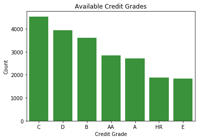

```python
#Checking the distribution of the credit grades
base_color = sb.color_palette()[2]
grade_order = loan_sub['creditgrade'].value_counts().index
sb.countplot(data=loan_sub, x = 'creditgrade', color = base_color, order = grade_order)
plt.xlabel('Credit Grade')
plt.ylabel('Count')
plt.title('Available Credit Grades');
```

From the plot, it is obvious that a large proportion of the customers are on the C credit grade, followed by D with HR and E at the bottom.

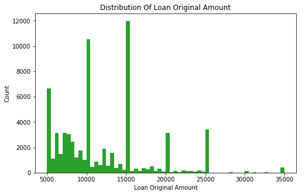

```python
#Taking a look at the distribution of loan amount
plt.figure(figsize=(8,5))
base_color=sb.color_palette()[2]
bins = np.arange(5000, loan_sub['loanoriginalamount'].max()+500, 500)
plt.hist(data = loan_sub, x = 'loanoriginalamount', color=base_color,bins = bins);
plt.xlabel('Loan Original Amount')
plt.ylabel('Count')
plt.title('Distribution Of Loan Original Amount');
```

The graph tends towards the left, showing that most loans collected are less than 30000.

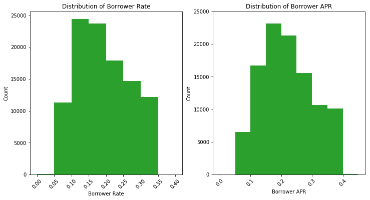

```python
#Plotting the borrower rate and borrow apr to see if there is a significant difference
base_color = sb.color_palette()[2]
plt.figure(figsize = (12,6))

plt.subplot(1,2,1)
bins= np.arange(0, loan_sub['borrowerrate'].max()+0.05, 0.05)
plt.hist(data =loan_sub, x = 'borrowerrate', color = base_color, bins=bins)
plt.xticks(rotation = 45)
plt.xlabel('Borrower Rate')
plt.ylabel('Count')
plt.title('Distribution of Borrower Rate');

plt.subplot(1,2,2)
bins= np.arange(0, loan_sub['borrowerapr'].max()+0.05, 0.05)
plt.hist(data =loan_sub, x= 'borrowerapr', color = base_color, bins = bins)
plt.xticks(rotation = 45)
plt.xlabel('Borrower APR')
plt.ylabel('Count')
plt.ylim(0, 25000)
plt.title('Distribution of Borrower APR');
```

Despite the fact that there are few loans beyond 0.4, the borrower apr still has quite some loans more than the borrower rate.

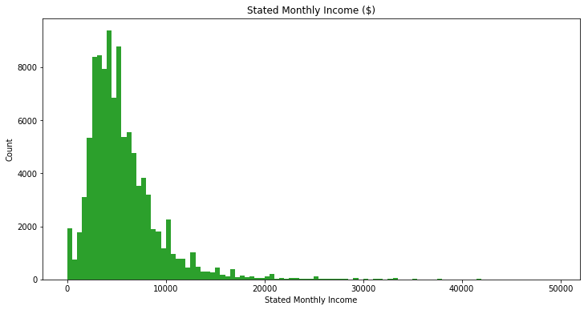

```python
#Checking Stated Monthly Income distribution
plt.figure(figsize=(12,6))
base_color=sb.color_palette()[2]
bins = np.arange(0, 50000, 500)
plt.hist(data = loan_sub, x = 'statedmonthlyincome', color=base_color,bins=bins)
plt.xlabel('Stated Monthly Income')
plt.ylabel('Count')
plt.title('Stated Monthly Income ($)');
```

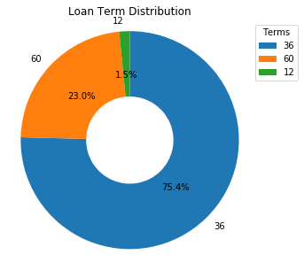

```python
#Loan term distribution
plt.figure(figsize=(10,5))
loan_term=loan_sub['term'].value_counts()
labels = [12,36,60]
plt.pie(loan_term,labels=loan_term.index,startangle=90,wedgeprops={'width':0.6},counterclock=False, autopct='%1.1f%%')
plt.axis('square')
plt.legend(title='Terms', bbox_to_anchor =(1,1))
plt.title('Loan Term Distribution');
```

Most of the loan term are within 36months. I would like to see how this compares with the loan status.

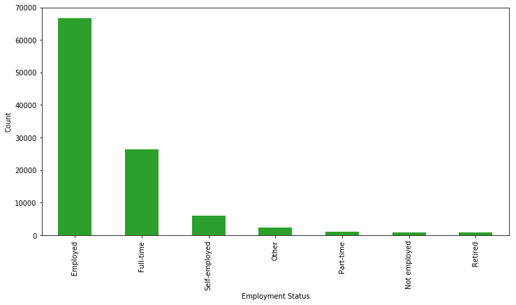

```python
#Checking the distribution of borrowers
plt.figure(figsize=(12,6))
base_color = sb.color_palette()[2]
loan_sub['employmentstatus'].value_counts().plot(kind='bar',color = base_color)
plt.xlabel('Employment Status')
plt.ylabel('Count')
plt.xticks(rotation=90);
```

Apparently, a vast number of the loan-takers are employed. I would like to believe that the full-time also refers to being employed.

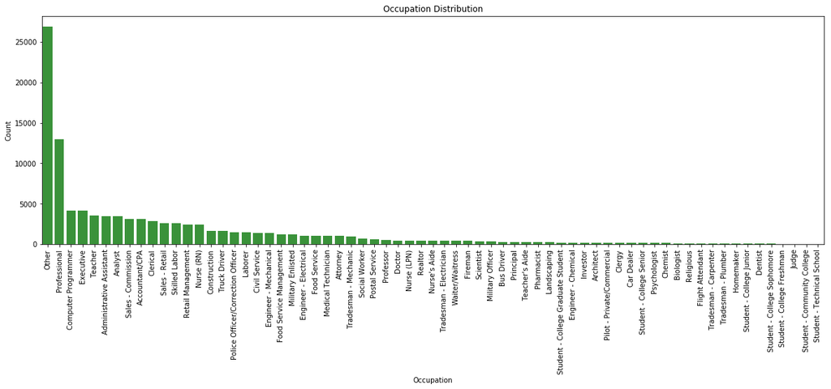

```python
#Checking distribution of employment status of the borrower.
base_color = sb.color_palette()[2]
occupation_order=loan_sub['occupation'].value_counts().index
plt.figure(figsize=(20,6))
sb.countplot(data = loan_sub, x= 'occupation', color = base_color, order=occupation_order)
plt.xlabel('Occupation')
plt.ylabel('Count')
plt.title('Occupation Distribution')
plt.xticks(rotation = 90);
```

This graph was plotted out of curiosity to see the distribution of the occupationt, since from the previous graph on employment status, a vast majority of the loan-takers are employed.

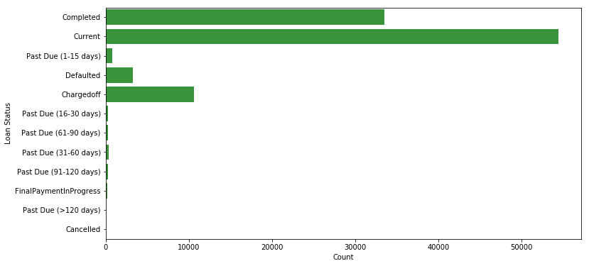

```python
#Checking loan payment statuses
plt.figure(figsize=(12,6))
base_color = sb.color_palette()[2]
sb.countplot(data=loan_sub, y = 'loanstatus', color = base_color)
plt.xlabel('Count')
plt.ylabel('Loan Status');
```

```python
#Compiling all Past Due values together
loan_sub.loc[loan_sub['loanstatus'].str.contains('Past Due '), 'loanstatus'] = 'Past Due'
loan_sub[loan_sub['loanstatus']=="Past Due"]
```

|  | creditgrade | borrowerrate | borrowerapr | lenderyield | occupation | employmentstatus | employmentstatusduration | statedmonthlyincome | loanstatus | term | loanoriginalamount |
| --- | --- | --- | --- | --- | --- | --- | --- | --- | --- | --- | --- |
| 12 | NaN | 0.1435 | 0.17969 | 0.1335 | Sales - Retail | Employed | 1.0 | 2416.666667 | Past Due | 36 | 4000 |
| 82 | NaN | 0.2932 | 0.33286 | 0.2832 | Other | Employed | 47.0 | 4166.666667 | Past Due | 36 | 4000 |
| 139 | NaN | 0.2999 | 0.33973 | 0.2899 | Other | Other | 111.0 | 1835.416667 | Past Due | 36 | 2500 |
| 508 | NaN | 0.2699 | 0.30532 | 0.2599 | Nurse's Aide | Employed | 48.0 | 2099.000000 | Past Due | 36 | 4500 |
| 597 | NaN | 0.1551 | 0.17849 | 0.1451 | Retail Management | Employed | 53.0 | 5533.333333 | Past Due | 60 | 23500 |
| 622 | NaN | 0.1169 | 0.13942 | 0.1069 | Tradesman - Electrician | Employed | 161.0 | 10416.666667 | Past Due | 60 | 20000 |
| 647 | NaN | 0.2179 | 0.24282 | 0.2079 | Professional | Employed | 133.0 | 4583.333333 | Past Due | 60 | 10000 |
| 673 | NaN | 0.1385 | 0.16151 | 0.1285 | Other | Employed | 100.0 | 3666.666667 | Past Due | 60 | 22500 |
| 750 | NaN | 0.1734 | 0.21025 | 0.1634 | Professor | Employed | 33.0 | 4750.000000 | Past Due | 36 | 10000 |
| 884 | NaN | 0.1639 | 0.20053 | 0.1539 | Teacher | Employed | 69.0 | 5000.000000 | Past Due | 36 | 15000 |
| 921 | NaN | 0.3177 | 0.35797 | 0.3077 | Other | Other | 205.0 | 1666.666667 | Past Due | 36 | 4000 |
| 994 | NaN | 0.3177 | 0.35797 | 0.3077 | Executive | Employed | 101.0 | 3333.333333 | Past Due | 36 | 4000 |
| 1051 | NaN | 0.1509 | 0.18725 | 0.1409 | Analyst | Employed | 18.0 | 5835.666667 | Past Due | 36 | 15000 |
| 1055 | NaN | 0.1129 | 0.13413 | 0.1029 | Sales - Commission | Full-time | 123.0 | 10000.000000 | Past Due | 36 | 13000 |
| 1063 | NaN | 0.2024 | 0.23990 | 0.1924 | Other | Employed | 89.0 | 2634.666667 | Past Due | 36 | 3000 |
| 1082 | NaN | 0.3177 | 0.35797 | 0.3077 | Professional | Employed | 172.0 | 4583.333333 | Past Due | 36 | 4000 |
| 1114 | NaN | 0.2699 | 0.30532 | 0.2599 | Retail Management | Employed | 52.0 | 2083.333333 | Past Due | 36 | 8000 |
| 1127 | NaN | 0.3177 | 0.35797 | 0.3077 | Skilled Labor | Employed | 85.0 | 4750.000000 | Past Due | 36 | 4000 |
| 1164 | NaN | 0.2124 | 0.25013 | 0.2024 | Other | Employed | 33.0 | 6666.666667 | Past Due | 36 | 15000 |
| 1166 | NaN | 0.2862 | 0.31293 | 0.2762 | Police Officer/Correction Officer | Employed | 103.0 | 7273.166667 | Past Due | 60 | 4000 |
| 1301 | NaN | 0.2699 | 0.29371 | 0.2599 | Analyst | Employed | 43.0 | 6064.583333 | Past Due | 60 | 15000 |
| 1419 | NaN | 0.2809 | 0.30748 | 0.2709 | Military Enlisted | Employed | 79.0 | 6500.000000 | Past Due | 60 | 4000 |
| 1437 | NaN | 0.1679 | 0.20462 | 0.1579 | Other | Employed | 4.0 | 1750.000000 | Past Due | 36 | 8000 |
| 1492 | NaN | 0.3199 | 0.35643 | 0.3099 | Laborer | Employed | 6.0 | 1833.333333 | Past Due | 36 | 4000 |
| 1522 | NaN | 0.3134 | 0.35356 | 0.3034 | Teacher | Employed | 58.0 | 2500.000000 | Past Due | 36 | 4000 |
| 1529 | NaN | 0.2489 | 0.27462 | 0.2389 | Other | Not employed | 8.0 | 0.000000 | Past Due | 60 | 5000 |
| 1540 | NaN | 0.3177 | 0.35797 | 0.3077 | Other | Self-employed | 90.0 | 3666.666667 | Past Due | 36 | 4000 |
| 1659 | NaN | 0.2179 | 0.24282 | 0.2079 | Professional | Employed | 184.0 | 3583.333333 | Past Due | 60 | 10000 |
| 1739 | NaN | 0.2492 | 0.28780 | 0.2392 | Retail Management | Employed | 109.0 | 2333.333333 | Past Due | 36 | 4000 |
| 1796 | NaN | 0.2859 | 0.32538 | 0.2759 | Other | Employed | 43.0 | 4166.666667 | Past Due | 36 | 4000 |
| ... | ... | ... | ... | ... | ... | ... | ... | ... | ... | ... | ... |
| 112784 | NaN | 0.2024 | 0.22693 | 0.1924 | Other | Not employed | 16.0 | 0.000000 | Past Due | 60 | 11500 |
| 112819 | NaN | 0.3127 | 0.35285 | 0.3027 | Food Service | Self-employed | 28.0 | 2666.666667 | Past Due | 36 | 4000 |
| 112821 | NaN | 0.1764 | 0.20564 | 0.1664 | Other | Not employed | 7.0 | 0.000000 | Past Due | 36 | 5750 |
| 112824 | NaN | 0.2209 | 0.24589 | 0.2109 | Other | Employed | 22.0 | 7083.333333 | Past Due | 60 | 15000 |
| 112866 | NaN | 0.2024 | 0.22693 | 0.1924 | Accountant/CPA | Employed | 25.0 | 4333.333333 | Past Due | 60 | 9000 |
| 112892 | NaN | 0.3149 | 0.35132 | 0.3049 | Other | Employed | 8.0 | 4333.333333 | Past Due | 36 | 7500 |
| 112895 | NaN | 0.3177 | 0.35797 | 0.3077 | Clerical | Employed | 156.0 | 3000.000000 | Past Due | 36 | 4000 |
| 112917 | NaN | 0.3177 | 0.35797 | 0.3077 | Other | Self-employed | 77.0 | 0.000000 | Past Due | 36 | 3000 |
| 112939 | NaN | 0.2867 | 0.31344 | 0.2767 | Civil Service | Employed | 57.0 | 7750.000000 | Past Due | 60 | 15000 |
| 112994 | NaN | 0.2346 | 0.27285 | 0.2246 | Other | Other | 85.0 | 3500.000000 | Past Due | 36 | 4000 |
| 113028 | NaN | 0.2272 | 0.26528 | 0.2172 | Administrative Assistant | Employed | 271.0 | 3250.000000 | Past Due | 36 | 10000 |
| 113060 | NaN | 0.3177 | 0.35797 | 0.3077 | Other | Employed | 157.0 | 6375.000000 | Past Due | 36 | 4000 |
| 113072 | NaN | 0.0899 | 0.11766 | 0.0799 | Computer Programmer | Employed | 16.0 | 11820.416667 | Past Due | 36 | 8000 |
| 113098 | NaN | 0.1223 | 0.14494 | 0.1123 | Food Service | Full-time | 94.0 | 2083.333333 | Past Due | 60 | 15000 |
| 113138 | NaN | 0.2699 | 0.30532 | 0.2599 | Other | Employed | 214.0 | 4416.666667 | Past Due | 36 | 10000 |
| 113181 | NaN | 0.2999 | 0.33973 | 0.2899 | Executive | Employed | 13.0 | 20000.000000 | Past Due | 36 | 4000 |
| 113211 | NaN | 0.2099 | 0.23462 | 0.1999 | Other | Employed | 4.0 | 4166.666667 | Past Due | 60 | 10000 |
| 113289 | NaN | 0.1199 | 0.12211 | 0.1099 | Other | Other | 8.0 | 3133.333333 | Past Due | 60 | 14000 |
| 113363 | NaN | 0.2699 | 0.30532 | 0.2599 | Realtor | Self-employed | 27.0 | 3750.000000 | Past Due | 36 | 6500 |
| 113434 | NaN | 0.2557 | 0.28160 | 0.2457 | Teacher | Employed | 100.0 | 6250.000000 | Past Due | 60 | 10000 |
| 113456 | NaN | 0.1346 | 0.15752 | 0.1246 | Other | Employed | 22.0 | 3566.666667 | Past Due | 60 | 25000 |
| 113507 | NaN | 0.3177 | 0.35797 | 0.3077 | Other | Other | 483.0 | 8333.333333 | Past Due | 36 | 4000 |
| 113509 | NaN | 0.2862 | 0.31293 | 0.2762 | Food Service | Employed | 34.0 | 833.333333 | Past Due | 60 | 2000 |
| 113575 | NaN | 0.3199 | 0.35643 | 0.3099 | Other | Other | 99.0 | 3779.250000 | Past Due | 36 | 7500 |
| 113653 | NaN | 0.3177 | 0.35797 | 0.3077 | Clerical | Full-time | 146.0 | 2083.333333 | Past Due | 36 | 4000 |
| 113697 | NaN | 0.2487 | 0.28728 | 0.2387 | Professional | Employed | 146.0 | 7583.333333 | Past Due | 36 | 4000 |
| 113700 | NaN | 0.2346 | 0.27285 | 0.2246 | Executive | Employed | 14.0 | 14000.000000 | Past Due | 36 | 12500 |
| 113748 | NaN | 0.2786 | 0.31790 | 0.2686 | Other | Other | 77.0 | 5445.000000 | Past Due | 36 | 4000 |
| 113769 | NaN | 0.2786 | 0.31790 | 0.2686 | Analyst | Employed | 169.0 | 6333.333333 | Past Due | 36 | 2600 |
| 113875 | NaN | 0.3149 | 0.35132 | 0.3049 | Administrative Assistant | Employed | 97.0 | 4702.166667 | Past Due | 36 | 5000 |

2044 rows × 11 columns

```python
loan_sub['loanstatus'].value_counts()
```

```
Current                   54455
Completed                 33517
Chargedoff                10626
Defaulted                  3291
Past Due                   2044
FinalPaymentInProgress      201
Cancelled                     1
Name: loanstatus, dtype: int64
```

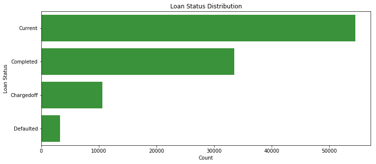

```python
#From the previous graph some of the values had insignificant counts, therefore the plot was done again limiting the display to sifnificant values.
plt.figure(figsize=(12,5))
base_color = sb.color_palette()[2]
loan_status = loan_sub.loc[loan['loanstatus'].isin(['Completed', 'Current', 'Defaulted', 'Chargedoff'])]
loan_order = loan_status['loanstatus'].value_counts().index
sb.countplot(data = loan_status, y='loanstatus', color = base_color, order=loan_order)
plt.xlabel('Count')
plt.ylabel('Loan Status')
plt.title('Loan Status Distribution');
```

The previous graph shows a full status of the loan payment, however, the second graph became necessary as most of the other categories have no value. From the chart, it is obvious that most loans are paid on time.

### Of the features you investigated, were there any unusual distributions? Did you perform any operations on the data to tidy, adjust, or change the form of the data? If so, why did you do this?

> I removed duplicates and null values in order to get a clear view of the distribution. On the loan original amount, most loans were less than 30,000 dollars and just a bit at 35,000 dollars which can be viewed as an outlier.

## Bivariate Exploration

First, the correlation between these variables was investigated

```python
num_vars = ['borrowerrate', 'borrowerapr', 'statedmonthlyincome', 'loanoriginalamount']
cat_vars = ['term', 'lenderyield', 'employmentstatus']
```

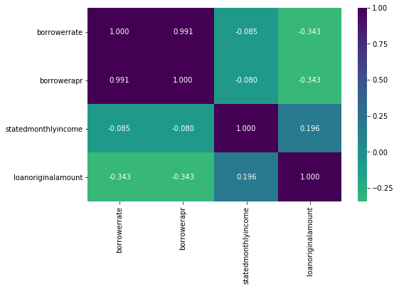

```python
# correlation plot
plt.figure(figsize = [8, 5])
sb.heatmap(loan_sub[num_vars].corr(), annot = True, fmt = '.3f',
           cmap = 'viridis_r', center = 0);
```

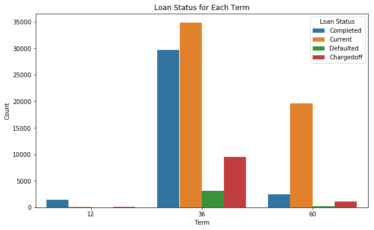

```python
#Checking the loan payment status according to the terms
plt.figure(figsize=(10,6))
loan_status = loan_sub.loc[loan['loanstatus'].isin(['Completed', 'Current', 'Defaulted', 'Chargedoff'])]
sb.countplot(data=loan_status, x='term',hue='loanstatus')
plt.xlabel('Term')
plt.ylabel('Count')
plt.title('Loan Status for Each Term')
plt.legend(title='Loan Status');
```

From the univariate plot, I was really interested in the loan status relationship with the terms. Based on the plot, loan term of 36month is a comfortable timeframe for loans to be repaid. However, I look forward to see if this is related to the stated monthly income.

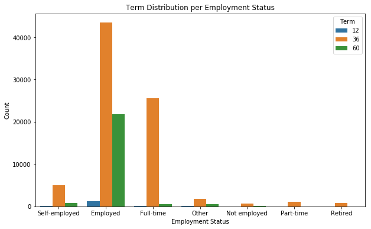

```python
#Checking the loan term status according to the employment status
plt.figure(figsize=(10,6))
sb.countplot(data=loan_sub, x='employmentstatus',hue='term')
plt.xlabel('Employment Status')
plt.ylabel('Count')
plt.title('Term Distribution per Employment Status')
plt.legend(title='Term');
```

Again, this validates the previous plot as most of those who took loan within 36months period are employed and Fulltime

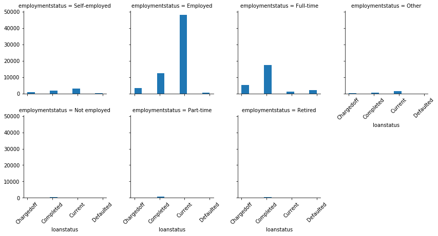

```python
loan_status = loan_sub.loc[loan['loanstatus'].isin(['Completed', 'Current', 'Defaulted', 'Chargedoff'])]

ax = sb.FacetGrid(data = loan_status, col = 'employmentstatus', col_wrap = 4, size = 3)
ax.map(plt.hist, 'loanstatus')
ax.set_xticklabels(rotation=45);
```

Taking a closer look at the loan status and employment status, it shows that those who take loans are usually the employed, thus making it easier for the loans to be repaid.

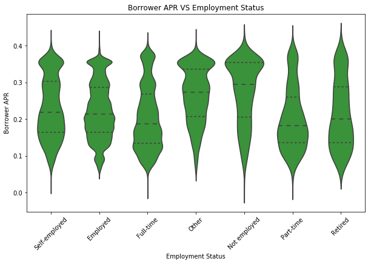

```python
plt.figure(figsize=(10,6))
base_color=sb.color_palette()[2]
sb.violinplot(data =loan_sub,x='employmentstatus', y ='borrowerapr',color=base_color, inner ='quartile')
plt.xlabel('Employment Status')
plt.ylabel('Borrower APR')
plt.title('Borrower APR VS Employment Status')
plt.xticks(rotation=45);
```

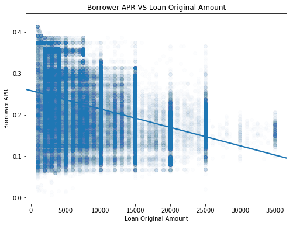

```python
#Taking a look at the apr relative to the loan amount
plt.figure(figsize = [8, 6])
sb.regplot(data = loan_sub, x = 'loanoriginalamount', y = 'borrowerapr', scatter_kws={'alpha':0.01})
plt.xlabel('Loan Original Amount')
plt.ylabel('Borrower APR')
plt.title('Borrower APR VS Loan Original Amount');
```

The plot shows the distribution between the loan original amount and borrower apr. With the increase loan amount, the borrower apr reduces. But then again, most of the loan amount is within 5000 - 15,000 dollars range.

### Talk about some of the relationships you observed in this part of the investigation. How did the feature(s) of interest vary with other features in the dataset?

> For this section, the relationship between the loan term and loan status was largely explored, as well as the employment status and loan status. 75.4% of the borrowers took loans for 36months term and most of them are employed and paid their loan on time.

### Did you observe any interesting relationships between the other features (not the main feature(s) of interest)?

> In terms of apr and loan amount, increase in the loan amount leads to a decrease in apr, thus, they are negatively correlated.

## Multivariate Exploration

> The major area to be explored here is the range of loan amount collected and category of persons who pay quickly. While this has been looked into in the bivariate plots, I want to see how multiple factors support or deviate from the results of the bivariate plot.

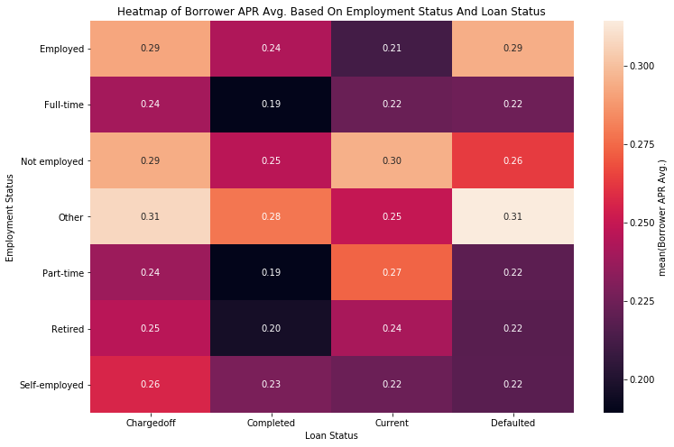

```python
plt.figure(figsize=(12,8))
loan_status = loan_sub.loc[loan['loanstatus'].isin(['Completed', 'Current', 'Defaulted', 'Chargedoff'])]
mn_borrow = loan_status.groupby(['loanstatus', 'employmentstatus']).mean()['borrowerapr']
mn_borrow = mn_borrow.reset_index(name = 'Borrower APR Avg.')
mn_borrow = mn_borrow.pivot(index = 'employmentstatus', columns = 'loanstatus',
                       values = 'Borrower APR Avg.')
sb.heatmap(mn_borrow, annot = True, fmt = '.2f', cbar_kws = {'label': 'mean(Borrower APR Avg.)'})
plt.xlabel('Loan Status')
plt.ylabel('Employment Status')
plt.title('Heatmap of Borrower APR Avg. Based On Employment Status And Loan Status');
```

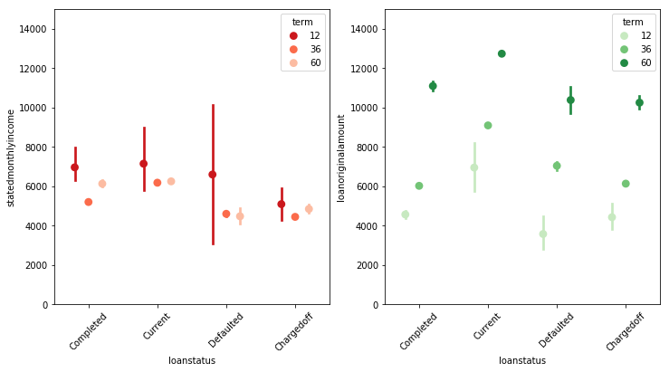

```python
plt.figure(figsize=[12,6])
plt.subplot(1,2,1)
sb.pointplot(data = loan_status, x = 'loanstatus', y = 'statedmonthlyincome', hue = 'term',
           palette = 'Reds_r', linestyles = '', dodge = 0.4)
plt.ylim(0,15000)
plt.xticks(rotation=45);

plt.subplot(1,2,2)
sb.pointplot(data = loan_status, x = 'loanstatus', y = 'loanoriginalamount', hue = 'term',
           palette = 'Greens', linestyles = '', dodge = 0.4)
plt.ylim(0,15000)
plt.xticks(rotation=45);
```

While the higher loan amount are on the 60months term and most of the loan amounts are paid.

```python
amt=loan_sub['loanoriginalamount'].max()
income=loan_sub['statedmonthlyincome'].max()

print(amt)
print(income)
```

```
35000
1750002.91667
```

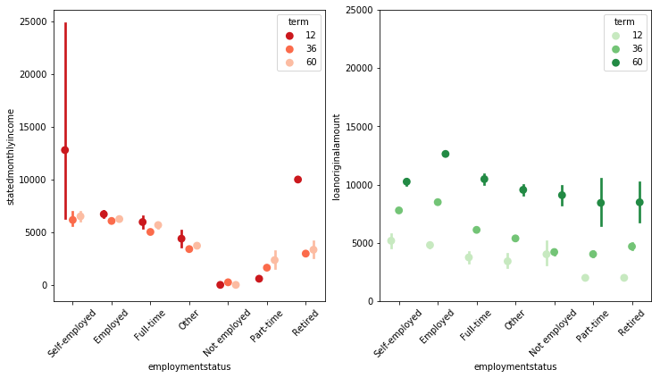

```python
plt.figure(figsize=[12,6])
plt.subplot(1,2,1)
sb.pointplot(data = loan_sub, x = 'employmentstatus', y = 'statedmonthlyincome', hue = 'term',
           palette = 'Reds_r', linestyles = '', dodge = 0.4)
plt.xticks(rotation=45);

plt.subplot(1,2,2)
sb.pointplot(data = loan_sub, x = 'employmentstatus', y = 'loanoriginalamount', hue = 'term',
           palette = 'Greens', linestyles = '', dodge = 0.4)
plt.ylim(0,25000)
plt.xticks(rotation=45);
```

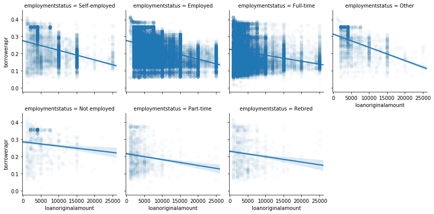

```python
g = sb.FacetGrid(data = loan_sub, col = 'employmentstatus', col_wrap = 4)
g.map(sb.regplot,'loanoriginalamount', 'borrowerapr', x_jitter = 0.05, scatter_kws = {'alpha': 0.02});
```